# Technoecom: Digital Transformation - Project 1

### Business Context:

In the contemporary era, electronic devices have become an integral part of everyday life, ranging from basic LED lights to cutting-edge laptops and 4K televisions. With such widespread demand for these products, many entrepreneurs have ventured into the electronic goods and services sector. Technoecom stands out as one of Australia's premier direct-to-consumer retailers in this domain. Offering an extensive array of over 500 top-notch electronic products sourced from global manufacturers, the company caters to diverse consumer needs across various categories.

Their product range spans gaming devices, accessories, wireless speakers, smartphones, laptop peripherals, entertainment systems, and high-end home appliances from luxury brands. Operating in more than 10 cities, Technoecom ensures nationwide accessibility by delivering products directly to customers' doorsteps.

In a strategic move towards digital transformation, the company has recently launched its e-commerce platform. This initiative aims to pilot sales and delivery operations through the online platform for a duration of three months, reflecting their commitment to staying at the forefront of technological advancements in retail.

### Problem Statement:

Transitioning to conducting business via an e-commerce platform has proven to be a challenging endeavor. Over the course of the past three months, Technoecom has encountered numerous obstacles spanning different areas, including payment methods, order volume, geographical coverage, expedited shipping, and customer satisfaction. Now, the company is seeking to assess the feasibility of expanding this digital transformation to additional cities and to evaluate the revenue generated from this pilot program.

### Objective:

The Chief Experience Officer (CXO) is keen on enhancing monitoring and diagnostic capabilities to ensure the company makes informed decisions. As the analytics lead, your role is to conduct data preprocessing and exploratory data analysis (EDA) to gain insights into the digital transformation initiative and submit a detailed analysis report. This report will provide the necessary information for the CXO to make informed decisions regarding the potential expansion of this digital transformation to other cities.

## Importing the required libraries

```python
# write you are code here
import numpy as np
import pandas as pd
import matplotlib.pyplot as plt
import seaborn as sns
from warnings import filterwarnings
filterwarnings('ignore')
```

## Dataset Import

Run the code written below. After running the code, Google Colab will ask you to upload the.csv file. Please upload the same.

```python
# write you are code here
df = pd.read_csv("technoecom.csv")
df
```

|  | customer_id | marital_status | occupation | education | warehouse_name | order_id | order_date | order_price | delivery_charges | coupon_discount | order_type | order_payment | is_expedited_delivery | distance_to_nearest_warehouse | customer_satisfaction | age | warehouse_area_type | warehouse_size | total_bill |
| --- | --- | --- | --- | --- | --- | --- | --- | --- | --- | --- | --- | --- | --- | --- | --- | --- | --- | --- | --- |
| 0 | ID0571731474 | Yes | Manager | Masters | Nickolson | ORD001041 | 13/06/2021 | 8725 | 66.86 | 15 | COD | Cash | False | 0.7237 | False | 24 | Commercial | Medium | 7483.11 |
| 1 | ID6167441063 | Yes | Clerical | School | Thompson | ORD004361 | 02/06/2021 | 22220 | 53.80 | 15 | COD | Cash | False | 1.4593 | False | 30 | Industrial | Large | 18940.80 |
| 2 | ID6221450539 | Yes | Lawyer | Masters | Nickolson | ORD004602 | 17/06/2021 | 10460 | 65.47 | 15 | COD | Debit Card | True | 1.0229 | True | 23 | Commercial | Medium | 8956.47 |
| 3 | ID2383211221 | Yes | Manager | High School | Nickolson | ORD004848 | 13/06/2021 | 15070 | 79.13 | 5 | COD | Debit Card | True | 1.0328 | True | 28 | Commercial | Medium | 14395.63 |
| 4 | ID0248129431 | No | Student | School | Nickolson | ORD005232 | 09/07/2021 | 5905 | 95.22 | 15 | COD | Credit Card | True | 0.1227 | True | 31 | Commercial | Medium | 5114.47 |
| ... | ... | ... | ... | ... | ... | ... | ... | ... | ... | ... | ... | ... | ... | ... | ... | ... | ... | ... | ... |
| 502 | ID3130999251 | No | Blue Collar | School | Thompson | ORD008127 | 30/07/2021 | 6770 | 77.13 | 5 | COD | Debit Card | False | 0.2540 | False | 31 | Industrial | Large | 6508.63 |
| 503 | ID2187983888 | Yes | Professional | Bachelors | Nickolson | ORD010057 | 18/05/2021 | 3085 | 53.47 | 10 | Prepaid | EMI | False | 1.3575 | False | 27 | Commercial | Medium | 2829.97 |
| 504 | ID3516648756 | Yes | Blue Collar | High School | Nickolson | ORD010677 | 18/07/2021 | 730 | 108.58 | 10 | COD | Credit Card | True | 1.6767 | True | 28 | Commercial | Medium | 765.58 |
| 505 | ID0363973195 | Yes | Blue Collar | High School | Bakers | ORD010913 | 01/06/2021 | 14175 | 55.71 | 10 | Prepaid | EMI | False | 94.9734 | False | 27 | Residential | Small | 12813.21 |
| 506 | ID6167417972 | Yes | Blue Collar | High School | Thompson | ORD014742 | 29/05/2021 | 15130 | 66.90 | 10 | Prepaid | Digital Wallet | False | 1.0975 | False | 30 | Industrial | Large | 13683.90 |

507 rows × 19 columns

## Understand the data

### Create a Copy of the Dataset

```python
tech_df = df.copy()
```

#### **Question 1:** How many rows and columns are present in the data?

```python
# write you are code here
print(tech_df.shape)

print("Total rows in the dataset:", tech_df.shape[0])
print("Total columns in the dataset:", tech_df.shape[1])
```

```
(507, 19)
Total rows in the dataset: 507
Total columns in the dataset: 19
```

##### From the datset presented, there are 507 observations and 19 variables.

#### **Question 2:** What are the datatypes of the different columns in the dataset?

```python
# write you are code here
tech_df.info()
```

```
<class 'pandas.core.frame.DataFrame'>
RangeIndex: 507 entries, 0 to 506
Data columns (total 19 columns):
 #   Column                         Non-Null Count  Dtype
---  ------                         --------------  -----
 0   customer_id                    507 non-null    object
 1   marital_status                 507 non-null    object
 2   occupation                     507 non-null    object
 3   education                      497 non-null    object
 4   warehouse_name                 507 non-null    object
 5   order_id                       507 non-null    object
 6   order_date                     507 non-null    object
 7   order_price                    507 non-null    int64
 8   delivery_charges               497 non-null    float64
 9   coupon_discount                507 non-null    int64
 10  order_type                     484 non-null    object
 11  order_payment                  490 non-null    object
 12  is_expedited_delivery          507 non-null    bool
 13  distance_to_nearest_warehouse  507 non-null    float64
 14  customer_satisfaction          507 non-null    bool
 15  age                            507 non-null    int64
 16  warehouse_area_type            507 non-null    object
 17  warehouse_size                 507 non-null    object
 18  total_bill                     507 non-null    float64
dtypes: bool(2), float64(3), int64(3), object(11)
memory usage: 68.5+ KB
```

##### There are 3 Float variables, 3 Integer variables, 2 Boolean variables and 11 object variables in the data set.

- In the dataset, we do not think that the customer_id and order_id variables/columns would be useful to draw meaningful insights.
- As such, we will drop the customer_id and order_id columns to focus on the useful data.
- Also, there are 4 variables which have Null values and would be treated accordingly.
- At the moment, the order_date variable is an object. We might need to change it to a date-time variable if there will be a need for the data.

## Data Preprocessing

### Missing value Identification and Treatment

```python
tech_df.drop(['customer_id', 'order_id'], axis = 1, inplace = True)
tech_df.info()
```

```
<class 'pandas.core.frame.DataFrame'>
RangeIndex: 507 entries, 0 to 506
Data columns (total 17 columns):
 #   Column                         Non-Null Count  Dtype
---  ------                         --------------  -----
 0   marital_status                 507 non-null    object
 1   occupation                     507 non-null    object
 2   education                      497 non-null    object
 3   warehouse_name                 507 non-null    object
 4   order_date                     507 non-null    object
 5   order_price                    507 non-null    int64
 6   delivery_charges               497 non-null    float64
 7   coupon_discount                507 non-null    int64
 8   order_type                     484 non-null    object
 9   order_payment                  490 non-null    object
 10  is_expedited_delivery          507 non-null    bool
 11  distance_to_nearest_warehouse  507 non-null    float64
 12  customer_satisfaction          507 non-null    bool
 13  age                            507 non-null    int64
 14  warehouse_area_type            507 non-null    object
 15  warehouse_size                 507 non-null    object
 16  total_bill                     507 non-null    float64
dtypes: bool(2), float64(3), int64(3), object(9)
memory usage: 60.5+ KB
```

#### **Question 3:** Are there any missing values in the data? If so, treat them using an appropriate method.

```python
# write you are code here
tech_df.isna().sum()
```

```
marital_status                    0
occupation                        0
education                        10
warehouse_name                    0
order_date                        0
order_price                       0
delivery_charges                 10
coupon_discount                   0
order_type                       23
order_payment                    17
is_expedited_delivery             0
distance_to_nearest_warehouse     0
customer_satisfaction             0
age                               0
warehouse_area_type               0
warehouse_size                    0
total_bill                        0
dtype: int64
```

```python
tech_df['education'].fillna(tech_df['education'].mode().values[0], inplace = True)
tech_df['delivery_charges'].fillna(tech_df['delivery_charges'].median(), inplace = True)
tech_df['order_type'].fillna(tech_df['order_type'].mode().values[0], inplace = True)
tech_df['order_payment'].fillna(tech_df['order_payment'].mode().values[0], inplace = True)
```

- The missing values under education, order_type and order_payment variables were treated by replacing the null values with the value which has the most frequency in each variable. This is because the variables are categorical in nature.
- The missing values under delivery_charges were treated by replacing the null values with the median of delivery_charges. We used median and not mean because it is not affected by extreme values which the delivery_charges variable has.

```python
tech_df.isna().sum()
```

```
marital_status                   0
occupation                       0
education                        0
warehouse_name                   0
order_date                       0
order_price                      0
delivery_charges                 0
coupon_discount                  0
order_type                       0
order_payment                    0
is_expedited_delivery            0
distance_to_nearest_warehouse    0
customer_satisfaction            0
age                              0
warehouse_area_type              0
warehouse_size                   0
total_bill                       0
dtype: int64
```

#### **Question 4:** Check the statistical summary of the data.

```python
# write you are code here
tech_df.describe(include = 'all')
```

|  | marital_status | occupation | education | warehouse_name | order_date | order_price | delivery_charges | coupon_discount | order_type | order_payment | is_expedited_delivery | distance_to_nearest_warehouse | customer_satisfaction | age | warehouse_area_type | warehouse_size | total_bill |
| --- | --- | --- | --- | --- | --- | --- | --- | --- | --- | --- | --- | --- | --- | --- | --- | --- | --- |
| count | 507 | 507 | 507 | 507 | 507 | 507.000000 | 507.000000 | 507.000000 | 507 | 507 | 507 | 507.000000 | 507 | 507.000000 | 507 | 507 | 507.000000 |
| unique | 2 | 9 | 6 | 3 | 91 | NaN | NaN | NaN | 2 | 5 | 2 | NaN | 2 | NaN | 3 | 3 | NaN |
| top | Yes | Blue Collar | High School | Thompson | 14/07/2021 | NaN | NaN | NaN | Prepaid | Digital Wallet | False | NaN | True | NaN | Industrial | Large | NaN |
| freq | 272 | 94 | 156 | 200 | 13 | NaN | NaN | NaN | 321 | 142 | 256 | NaN | 263 | NaN | 200 | 200 | NaN |
| mean | NaN | NaN | NaN | NaN | NaN | 25169.739645 | 76.103452 | 12.869822 | NaN | NaN | NaN | 2.374596 | NaN | 27.297830 | NaN | NaN | 21843.925385 |
| std | NaN | NaN | NaN | NaN | NaN | 85785.462396 | 15.867656 | 7.557344 | NaN | NaN | NaN | 9.673633 | NaN | 2.902918 | NaN | NaN | 74053.432275 |
| min | NaN | NaN | NaN | NaN | NaN | 0.000000 | 0.000000 | 0.000000 | NaN | NaN | NaN | 0.107800 | NaN | 22.000000 | NaN | NaN | 68.240000 |
| 25% | NaN | NaN | NaN | NaN | NaN | 6877.500000 | 66.025000 | 10.000000 | NaN | NaN | NaN | 0.751700 | NaN | 25.000000 | NaN | NaN | 6000.675000 |
| 50% | NaN | NaN | NaN | NaN | NaN | 12765.000000 | 76.290000 | 15.000000 | NaN | NaN | NaN | 1.032800 | NaN | 27.000000 | NaN | NaN | 11059.890000 |
| 75% | NaN | NaN | NaN | NaN | NaN | 20325.000000 | 82.370000 | 15.000000 | NaN | NaN | NaN | 1.408650 | NaN | 30.000000 | NaN | NaN | 17662.385000 |
| max | NaN | NaN | NaN | NaN | NaN | 947691.000000 | 114.040000 | 25.000000 | NaN | NaN | NaN | 94.973400 | NaN | 32.000000 | NaN | NaN | 853012.720000 |

#### Observations

- Marital status has two unique values which surprisingly has a "Yes" or "No" response rather than "Married" or "Not Married".
- The occupation variable has nine unique values of which Blue Collar has the most reoccurrence.
- The order_price and total_bill variables are skewed to the right given their means is greater than their medians.
- However, the delivery_charges and age variables are almost normally distributed.
- The order_date is considered a string at the moment.

#### Question 5: Are there duplicates in the dataset, if so please treat them

```python
# write you are code here
print("Number of duplicate rows = %d" % tech_df.duplicated().sum())
```

```
Number of duplicate rows = 7
```

```python
tech_df.drop_duplicates(inplace = True)
print("Number of duplicate rows = %d" % tech_df.duplicated().sum())
```

```
Number of duplicate rows = 0
```

```python
tech_df.shape
```

```
(500, 17)
```

## Data Treatment

#### Let's check if there is any discrepancy in the values in the following columns: 'occupation' and 'education'.

```python
# write you are code here
print("Number of unique values in occupation: ", tech_df['occupation'].nunique())
print("Number of unique values in education: ", tech_df['education'].nunique())
print("Unique values under occupation: ", tech_df['occupation'].unique())
print("Unique values under education: ", tech_df['education'].unique())
```

```
Number of unique values in occupation:  9
Number of unique values in education:  6
Unique values under occupation:  ['Manager' 'Clerical' 'Lawyer' 'Student' 'Doctor' 'Blue Collar'
 'Professional' 'Home Maker' 'Blue-Collar']
Unique values under education:  ['Masters' 'School' 'High School' 'PhD' 'Bachelors' '?']
```

- Replace '?' in education with 'Unknown'
- Replace 'Blue-collar' with 'Blue Collar' in occupation

```python
# write you are code here
tech_df['education'].replace('?', 'Unknown', inplace = True)
tech_df['occupation'].replace('Blue-Collar', 'Blue Collar', inplace = True)
```

```python
print("Number of unique values in occupation: ", tech_df['occupation'].nunique())
print("Number of unique values in education: ", tech_df['education'].nunique())
print("Unique values under occupation: ", tech_df['occupation'].unique())
print("Unique values under education: ", tech_df['education'].unique())
```

```
Number of unique values in occupation:  8
Number of unique values in education:  6
Unique values under occupation:  ['Manager' 'Clerical' 'Lawyer' 'Student' 'Doctor' 'Blue Collar'
 'Professional' 'Home Maker']
Unique values under education:  ['Masters' 'School' 'High School' 'PhD' 'Bachelors' 'Unknown']
```

## Exploratory Data Analysis (EDA)

#### Now, after handling the missing values and also checking the data types, let's visualise the dataset.

### Univariate Analysis

Perform univariate and bivariate analyses on different columns of the data and write the observations that you got from the charts and plots

### Categorical

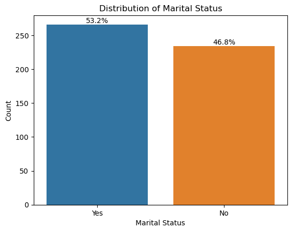

```python
ms = sns.countplot(data=tech_df, x='marital_status')

# Calculate the percentage of each category
total = len(tech_df)
for p in ms.patches:
    height = p.get_height()
    percentage = (height / total) * 100
    ms.annotate(f'{percentage:.1f}%', (p.get_x() + p.get_width() / 2, height),
                ha='center', va='bottom')

plt.xlabel('Marital Status')
plt.ylabel('Count')
plt.title('Distribution of Marital Status')
plt.show()
```

- From the dataset provided, 53.2% are married while 46.8% are not married.

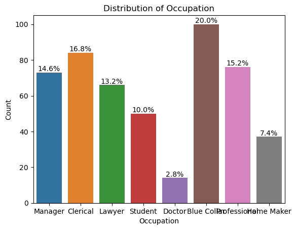

```python
oc = sns.countplot(data=tech_df, x='occupation')

# Calculate the percentage of each category
total = len(tech_df)
for p in oc.patches:
    height = p.get_height()
    percentage = (height / total) * 100
    oc.annotate(f'{percentage:.1f}%', (p.get_x() + p.get_width() / 2, height),
                ha='center', va='bottom')

plt.xlabel('Occupation')
plt.ylabel('Count')
plt.title('Distribution of Occupation')
plt.show()
```

- The top three Technoecom clientele include Blue Collar (20.0%), Clerical (16.8%) and Professional (15.2%).
- Doctors represent 2.8% of the customer base, probably because they have no need for most of the product on offer except laptop peripherals.

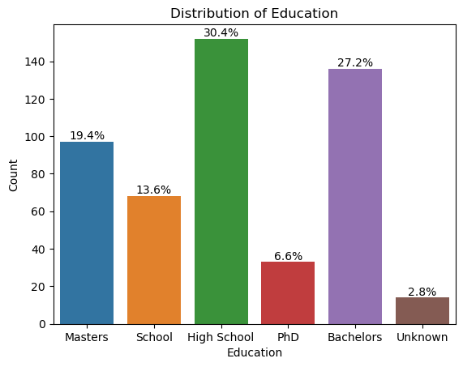

```python
edu = sns.countplot(data=tech_df, x='education')

# Calculate the percentage of each category
total = len(tech_df)
for p in edu.patches:
    height = p.get_height()
    percentage = (height / total) * 100
    edu.annotate(f'{percentage:.1f}%', (p.get_x() + p.get_width() / 2, height),
                ha='center', va='bottom')

plt.xlabel('Education')
plt.ylabel('Count')
plt.title('Distribution of Education')
plt.show()
```

- Individuals with a high school and bachelors certificate make up majority of the customer base.
- This is synonymous with the occupation data given that majority of Blue Collar jobs involve individuals who have only a high school or bachelors certificate.
- Most likely, majority of PhD holders would be doctor.
- However, 2.8% of the customer base did not declare their educational background.

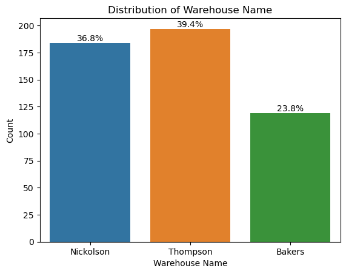

```python
ware_name = sns.countplot(data=tech_df, x='warehouse_name')

# Calculate the percentage of each category
total = len(tech_df)
for p in ware_name.patches:
    height = p.get_height()
    percentage = (height / total) * 100
    ware_name.annotate(f'{percentage:.1f}%', (p.get_x() + p.get_width() / 2, height),
                ha='center', va='bottom')

plt.xlabel('Warehouse Name')
plt.ylabel('Count')
plt.title('Distribution of Warehouse Name')
plt.show()
```

- Majority of deliveries were done from the Thompson warehouse which accounted for 39.4%.
- This was followed by Nickolson and Bakers warehouse with 36.8% and 23.8% respectively.

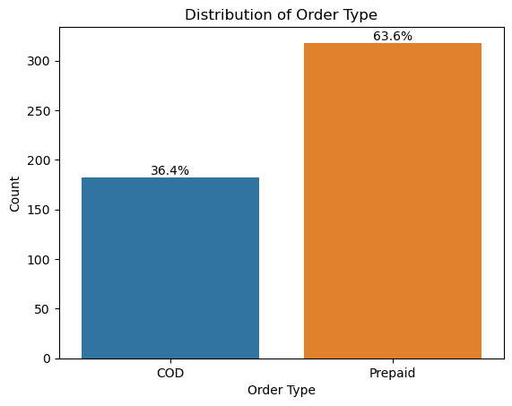

```python
ot = sns.countplot(data=tech_df, x='order_type')

# Calculate the percentage of each category
total = len(tech_df)
for p in ot.patches:
    height = p.get_height()
    percentage = (height / total) * 100
    ot.annotate(f'{percentage:.1f}%', (p.get_x() + p.get_width() / 2, height),
                ha='center', va='bottom')

plt.xlabel('Order Type')
plt.ylabel('Count')
plt.title('Distribution of Order Type')
plt.show()
```

- 63.6% of the customer base made payment for their order before delivery was made while 36.4% paid cash on delivery.
- This could indicate the level of trust Technoecom's customers have in the quality of the product delivered.

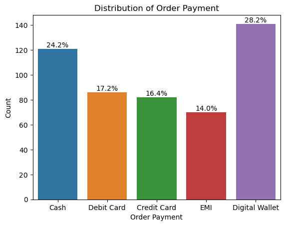

```python
op = sns.countplot(data=tech_df, x='order_payment')

# Calculate the percentage of each category
total = len(tech_df)
for p in op.patches:
    height = p.get_height()
    percentage = (height / total) * 100
    op.annotate(f'{percentage:.1f}%', (p.get_x() + p.get_width() / 2, height),
                ha='center', va='bottom')

plt.xlabel('Order Payment')
plt.ylabel('Count')
plt.title('Distribution of Order Payment')
plt.show()
```

- Most customers made payment using their digital wallet (28.2%), showing the rise and acceptance of digital currencies in the economy.
- 24.2% of customers paid with cash. Only possible way this could be achieved would be at the point of delivery.
- Only 14.0% of the customer base made payment through EMI (Equated Monthly Installment). Customers who paid through EMI could have spread the payment across months because of the pricey nature of the purchased product.

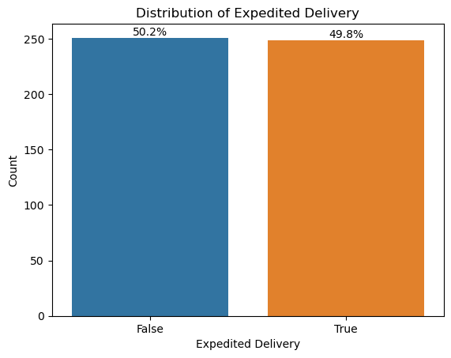

```python
ed = sns.countplot(data=tech_df, x='is_expedited_delivery')

# Calculate the percentage of each category
total = len(tech_df)
for p in ed.patches:
    height = p.get_height()
    percentage = (height / total) * 100
    ed.annotate(f'{percentage:.1f}%', (p.get_x() + p.get_width() / 2, height),
                ha='center', va='bottom')

plt.xlabel('Expedited Delivery')
plt.ylabel('Count')
plt.title('Distribution of Expedited Delivery')
plt.show()
```

- There is a balance between those who opt for normal delivery and expedited delivery.

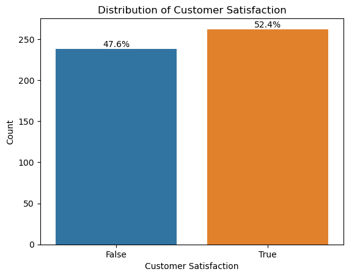

```python
cs = sns.countplot(data=tech_df, x='customer_satisfaction')

# Calculate the percentage of each category
total = len(tech_df)
for p in cs.patches:
    height = p.get_height()
    percentage = (height / total) * 100
    cs.annotate(f'{percentage:.1f}%', (p.get_x() + p.get_width() / 2, height),
                ha='center', va='bottom')

plt.xlabel('Customer Satisfaction')
plt.ylabel('Count')
plt.title('Distribution of Customer Satisfaction')
plt.show()
```

- While 52.4% of the customer base are satisfied, it is alarming that 47.6% of consumers are not pleased with their experience.
- Conducting a bivariate analysis between customer satisfaction and another variable could point out the cause of the dissatisfaction.

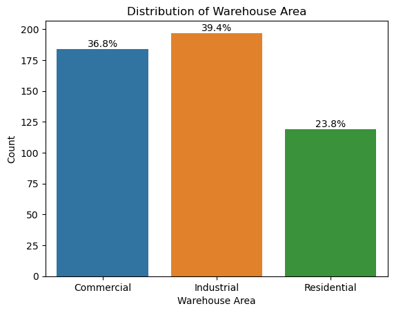

```python
wat = sns.countplot(data=tech_df, x='warehouse_area_type')

# Calculate the percentage of each category
total = len(tech_df)
for p in wat.patches:
    height = p.get_height()
    percentage = (height / total) * 100
    wat.annotate(f'{percentage:.1f}%', (p.get_x() + p.get_width() / 2, height),
                ha='center', va='bottom')

plt.xlabel('Warehouse Area')
plt.ylabel('Count')
plt.title('Distribution of Warehouse Area')
plt.show()
```

- There is no difference between deliveries made from where a warehouse is located and deliveries done from the available warehouses.
- This could mean that Thompson is located at an industrial area, Nickolson is located at a commercial area while Bakers is located at a residential area.

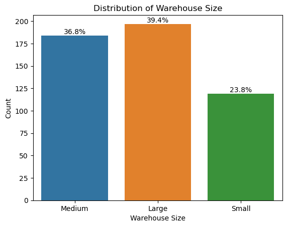

```python
ws = sns.countplot(data=tech_df, x='warehouse_size')

# Calculate the percentage of each category
total = len(tech_df)
for p in ws.patches:
    height = p.get_height()
    percentage = (height / total) * 100
    ws.annotate(f'{percentage:.1f}%', (p.get_x() + p.get_width() / 2, height),
                ha='center', va='bottom')

plt.xlabel('Warehouse Size')
plt.ylabel('Count')
plt.title('Distribution of Warehouse Size')
plt.show()
```

- There is no difference between warehouse_name, warehouse_area_type and warehouse_size.
- This means that Thompson is the largest warehouse located at an industrial area.
- Likewise, Nickolson is the medium warehouse located at a commerial area.
- Finally, Bakers is the smallest warehouse located at a residential area.

### Numerical

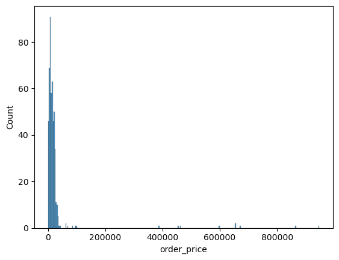

```python
sns.histplot(data= tech_df, x = 'order_price')
plt.show()
```

- The data is heavily skewed to the right.
- Most of the data points are clustered towards the left side of the graph, indicating lower order prices with higher counts/frequency.
- This rightward skewness suggests that there are relatively more low-priced orders and fewer high-priced orders in the dataset.

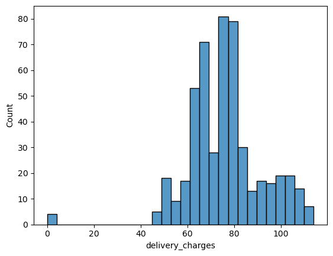

```python
sns.histplot(data= tech_df, x = 'delivery_charges')
plt.show()
```

- The data is skewed to the left.
- Most common delivery charges fall between 60 and 80.
- There are fewer counts as the delivery charges decrease or increase from this central range.

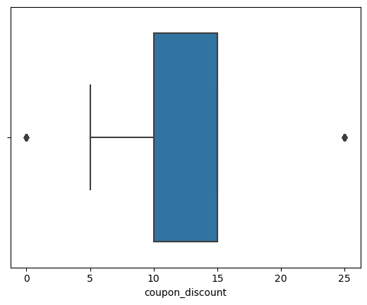

```python
sns.boxplot(data= tech_df, x = 'coupon_discount')
plt.show()
```

- Most coupon discount fall between 10.0% and 15.0%.

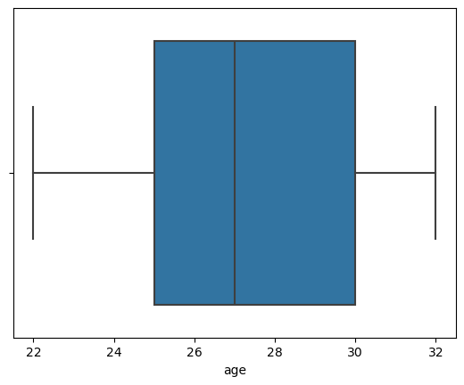

```python
sns.boxplot(data= tech_df, x = 'age')
plt.show()
```

- Majority of customers fall between the ages of 25 and 30.

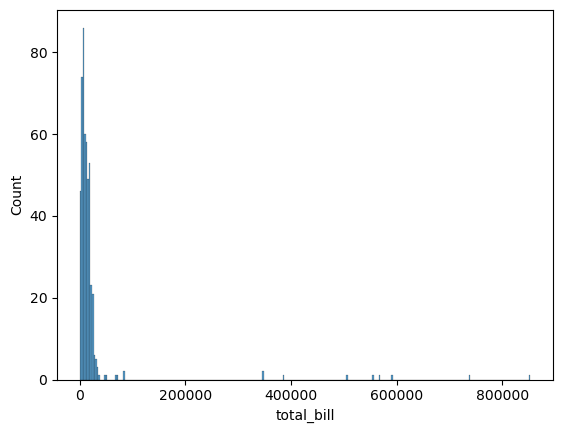

```python
sns.histplot(data= tech_df, x = 'total_bill')
plt.show()
```

- The data is heavily skewed to the right.
- Most of the data points are clustered towards the left side of the graph, indicating lower bills with higher counts/frequency.
- This rightward skewness suggests that there are relatively more low bills and fewer high bills in the dataset.

### Bivariate Analysis

Do the bivariate analysis between column name - "customer_satisfaction" and different integer and categorical variables and write down the observations

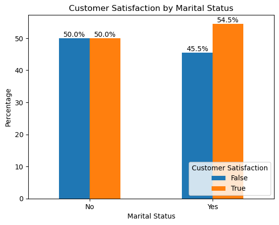

```python
# Create a cross-tabulation (crosstab) of marital status and customer satisfaction
ct = pd.crosstab(tech_df['marital_status'], tech_df['customer_satisfaction'])

# Calculate the percentage of each category within customer_satisfaction
ct_percentage = ct.div(ct.sum(axis=1), axis=0) * 100

# Plot the bar chart with percentages
ax = ct_percentage.plot(kind='bar')
plt.xlabel('Marital Status')
plt.ylabel('Percentage')
plt.title('Customer Satisfaction by Marital Status')
plt.legend(title='Customer Satisfaction', loc='lower right')
plt.xticks(rotation=0)  # Rotate x-axis labels if needed

# Add percentage labels to the bars
for p in ax.patches:
    height = p.get_height()
    ax.annotate(f'{height:.1f}%', (p.get_x() + p.get_width() / 2, height),
                ha='center', va='bottom')

plt.show()
```

- There is a 54.5% satisfaction level with customers who are married compared to 45.5% who were dissatisfied.
- There is an equal distribution of satisfaction and dissatisfaction among unmarried customers.

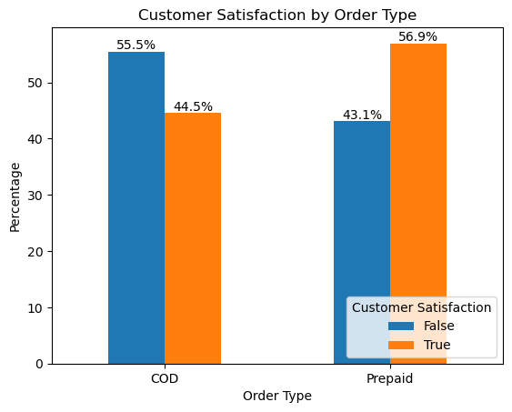

```python
# Create a cross-tabulation (crosstab) of order_type and customer satisfaction
ct = pd.crosstab(tech_df['order_type'], tech_df['customer_satisfaction'])

# Calculate the percentage of each category within customer_satisfaction
ct_percentage = ct.div(ct.sum(axis=1), axis=0) * 100

# Plot the bar chart with percentages
ax = ct_percentage.plot(kind='bar')
plt.xlabel('Order Type')
plt.ylabel('Percentage')
plt.title('Customer Satisfaction by Order Type')
plt.legend(title='Customer Satisfaction', loc='lower right')
plt.xticks(rotation=0)  # Rotate x-axis labels if needed

# Add percentage labels to the bars
for p in ax.patches:
    height = p.get_height()
    ax.annotate(f'{height:.1f}%', (p.get_x() + p.get_width() / 2, height),
                ha='center', va='bottom')

plt.show()
```

- There are more dissatisfied customers who paid with cash on delivery relative to those whose payment were made before delivery.
- The high level of dissatisfaction from cash on delivery (COD) could be a result of delayed delivery.

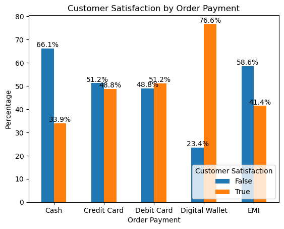

```python
# Create a cross-tabulation (crosstab) of order payment and customer satisfaction
ct = pd.crosstab(tech_df['order_payment'], tech_df['customer_satisfaction'])

# Calculate the percentage of each category within customer_satisfaction
ct_percentage = ct.div(ct.sum(axis=1), axis=0) * 100

# Plot the bar chart with percentages
ax = ct_percentage.plot(kind='bar')
plt.xlabel('Order Payment')
plt.ylabel('Percentage')
plt.title('Customer Satisfaction by Order Payment')
plt.legend(title='Customer Satisfaction', loc='lower right')
plt.xticks(rotation=0)  # Rotate x-axis labels if needed

# Add percentage labels to the bars
for p in ax.patches:
    height = p.get_height()
    ax.annotate(f'{height:.1f}%', (p.get_x() + p.get_width() / 2, height),
                ha='center', va='bottom')

plt.show()
```

## - Across board, satisfaction level was higher for only digital wallet (76.6%) and debit card (51.2%) payment option.

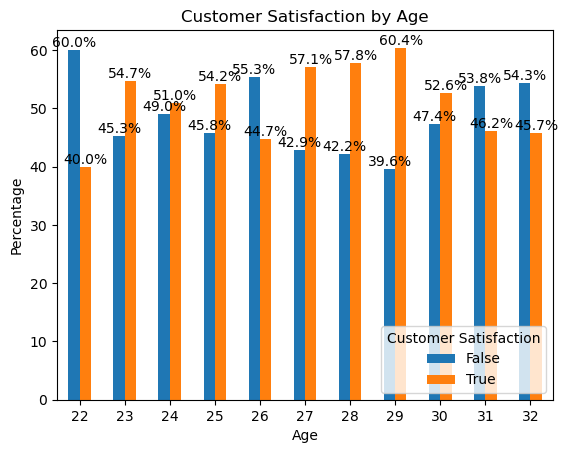

```python
# Create a cross-tabulation (crosstab) of age and customer satisfaction
ct = pd.crosstab(tech_df['age'], tech_df['customer_satisfaction'])

# Calculate the percentage of each category within customer_satisfaction
ct_percentage = ct.div(ct.sum(axis=1), axis=0) * 100

# Plot the bar chart with percentages
ax = ct_percentage.plot(kind='bar')
plt.xlabel('Age')
plt.ylabel('Percentage')
plt.title('Customer Satisfaction by Age')
plt.legend(title='Customer Satisfaction', loc='lower right')
plt.xticks(rotation=0)  # Rotate x-axis labels if needed

# Add percentage labels to the bars
for p in ax.patches:
    height = p.get_height()
    ax.annotate(f'{height:.1f}%', (p.get_x() + p.get_width() / 2, height),
                ha='center', va='bottom')


plt.show()
```

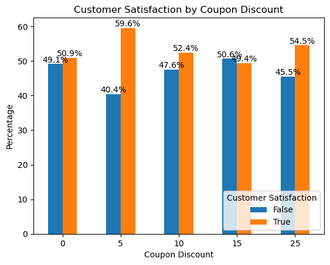

```python
# Create a cross-tabulation (crosstab) of coupon discounts and customer satisfaction
ct = pd.crosstab(tech_df['coupon_discount'], tech_df['customer_satisfaction'])

# Calculate the percentage of each category within customer_satisfaction
ct_percentage = ct.div(ct.sum(axis=1), axis=0) * 100

# Plot the bar chart with percentages
ax = ct_percentage.plot(kind='bar')
plt.xlabel('Coupon Discount')
plt.ylabel('Percentage')
plt.title('Customer Satisfaction by Coupon Discount')
plt.legend(title='Customer Satisfaction', loc='lower right')
plt.xticks(rotation=0)  # Rotate x-axis labels if needed

# Add percentage labels to the bars
for p in ax.patches:
    height = p.get_height()
    ax.annotate(f'{height:.1f}%', (p.get_x() + p.get_width() / 2, height),
                ha='center', va='bottom')

plt.show()
```

## - The satisfaction level was higher across board except for coupon discount of 15.0%.

The satisfaction level was higher for 5.0% and 25.0%.

## Outlier Treatment

Identify the columns in the dataset with the help of plots that was displayed above are required to treat outliers

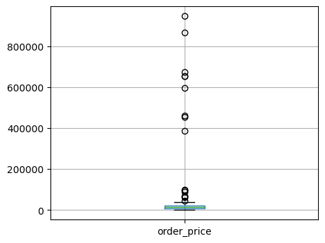

```python
# write you are code here
tech_df[['order_price']].boxplot(figsize = (5,4))
```

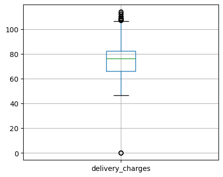

```python
tech_df[['delivery_charges']].boxplot(figsize = (5,4))
```

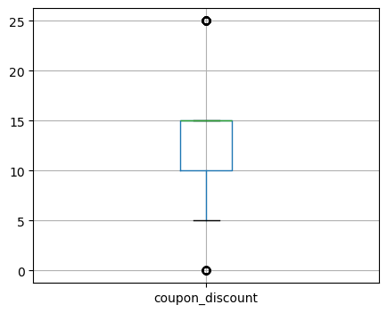

```python
tech_df[['coupon_discount']].boxplot(figsize = (5,4))
```

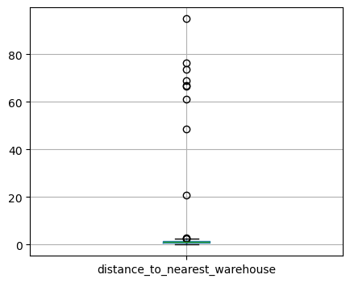

```python
tech_df[['distance_to_nearest_warehouse']].boxplot(figsize = (5,4))
```

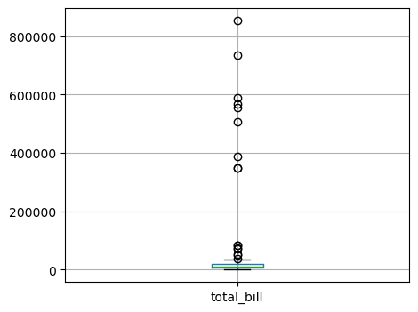

```python
tech_df[['total_bill']].boxplot(figsize = (5,4))
```

From the above, there are five variables (columns) - order_price, delivery_charges, coupon_discount, distance_to_nearest_warehouse and total_bill - that have outliers, and it needs to be treated.

#### Treating Order_price Outlier

```python
min_order_price, max_order_price = tech_df["order_price"].quantile([0.05, 0.95])
print(round(min_order_price, 2))
print(round(max_order_price, 2))
```

```
2522.75
31922.0
```

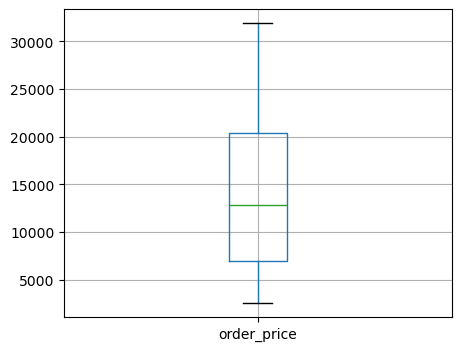

```python
tech_df["order_price"] = np.where(tech_df["order_price"] < min_order_price, min_order_price, tech_df["order_price"])
tech_df["order_price"] = np.where(tech_df["order_price"] > max_order_price, max_order_price, tech_df["order_price"])

tech_df[["order_price"]].boxplot(figsize = (5, 4))
```

#### Treating Delivery_charges Outlier

```python
min_delivery_charges, max_delivery_charges = tech_df["delivery_charges"].quantile([0.05, 0.95])
print(round(min_delivery_charges, 2))
print(round(max_delivery_charges, 2))
```

```
52.87
104.73
```

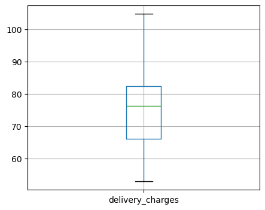

```python
tech_df["delivery_charges"] = np.where(tech_df["delivery_charges"] < min_delivery_charges, min_delivery_charges, tech_df["delivery_charges"])
tech_df["delivery_charges"] = np.where(tech_df["delivery_charges"] > max_delivery_charges, max_delivery_charges, tech_df["delivery_charges"])

tech_df[["delivery_charges"]].boxplot(figsize = (5, 4))
```

#### Treating Coupon_discount Outlier

```python
min_coupon_discount, max_coupon_discount = tech_df["coupon_discount"].quantile([0.05, 0.95])
print(round(min_coupon_discount, 2))
print(round(max_coupon_discount, 2))
```

```
0.0
25.0
```

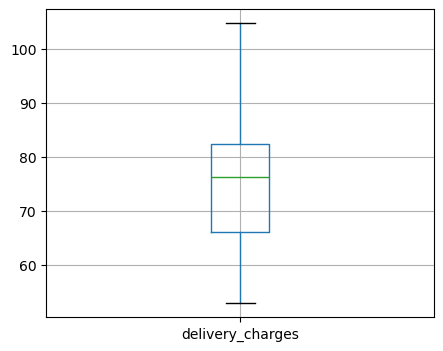

```python
tech_df["coupon_discount"] = np.where(tech_df["coupon_discount"] < min_coupon_discount, min_coupon_discount, tech_df["coupon_discount"])
tech_df["coupon_discount"] = np.where(tech_df["coupon_discount"] > max_coupon_discount, max_coupon_discount, tech_df["coupon_discount"])

tech_df[["delivery_charges"]].boxplot(figsize = (5, 4))
```

#### Treating Distance_to_nearest_warehouse Outlier

```python
min_distance_to_nearest_warehouse, max_distance_to_nearest_warehouse = tech_df["distance_to_nearest_warehouse"].quantile([0.05, 0.95])
print(round(min_distance_to_nearest_warehouse, 2))
print(round(max_distance_to_nearest_warehouse, 2))
```

```
0.34
1.99
```

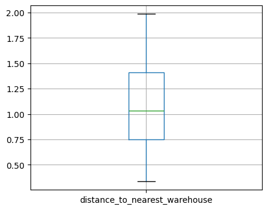

```python
tech_df["distance_to_nearest_warehouse"] = np.where(tech_df["distance_to_nearest_warehouse"] < min_distance_to_nearest_warehouse, min_distance_to_nearest_warehouse, tech_df["distance_to_nearest_warehouse"])
tech_df["distance_to_nearest_warehouse"] = np.where(tech_df["distance_to_nearest_warehouse"] > max_distance_to_nearest_warehouse, max_distance_to_nearest_warehouse, tech_df["distance_to_nearest_warehouse"])

tech_df[["distance_to_nearest_warehouse"]].boxplot(figsize = (5, 4))
```

#### Treating Total_bill Outlier

```python
min_total_bill, max_total_bill = tech_df["total_bill"].quantile([0.05, 0.95])
print(round(min_total_bill, 2))
print(round(max_total_bill, 2))
```

```
2271.62
28225.43
```

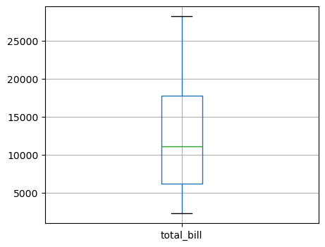

```python
tech_df["total_bill"] = np.where(tech_df["total_bill"] < min_total_bill, min_total_bill, tech_df["total_bill"])
tech_df["total_bill"] = np.where(tech_df["total_bill"] > max_total_bill, max_total_bill, tech_df["total_bill"])

tech_df[["total_bill"]].boxplot(figsize = (5, 4))
```

## Answer the following business questions based upon the data

##### [Q1] What is the revenue across each warehouse?

```python
# write you are code here
pd.options.display.float_format = '{:.2f}'.format

revenue_by_warehouse = tech_df.groupby("warehouse_name")["total_bill"].sum()

revenue_by_warehouse
```

```
warehouse_name
Bakers      1473743.73
Nickolson   2186312.55
Thompson    2478090.14
Name: total_bill, dtype: float64
```

##### [Q2] What is the distribution of orders across different months?

```python
# write you are code here
tech_df["order_date"] = pd.to_datetime(tech_df["order_date"])

tech_df["Month"] = tech_df["order_date"].dt.month

tech_df["Month"] = tech_df["Month"].replace([1, 2, 3, 4, 5, 6, 7, 8, 9, 10, 11, 12],
                                            ["January", "February", "March", "April", "May", "June", "July", "August", "September", "October", "November", "December"])

tech_df
```

|  | marital_status | occupation | education | warehouse_name | order_date | order_price | delivery_charges | coupon_discount | order_type | order_payment | is_expedited_delivery | distance_to_nearest_warehouse | customer_satisfaction | age | warehouse_area_type | warehouse_size | total_bill | Month |
| --- | --- | --- | --- | --- | --- | --- | --- | --- | --- | --- | --- | --- | --- | --- | --- | --- | --- | --- |
| 0 | Yes | Manager | Masters | Nickolson | 2021-06-13 | 8725.00 | 66.86 | 15.00 | COD | Cash | False | 0.72 | False | 24 | Commercial | Medium | 7483.11 | June |
| 1 | Yes | Clerical | School | Thompson | 2021-06-02 | 22220.00 | 53.80 | 15.00 | COD | Cash | False | 1.46 | False | 30 | Industrial | Large | 18940.80 | June |
| 2 | Yes | Lawyer | Masters | Nickolson | 2021-06-17 | 10460.00 | 65.47 | 15.00 | COD | Debit Card | True | 1.02 | True | 23 | Commercial | Medium | 8956.47 | June |
| 3 | Yes | Manager | High School | Nickolson | 2021-06-13 | 15070.00 | 79.13 | 5.00 | COD | Debit Card | True | 1.03 | True | 28 | Commercial | Medium | 14395.63 | June |
| 4 | No | Student | School | Nickolson | 2021-07-09 | 5905.00 | 95.22 | 15.00 | COD | Credit Card | True | 0.34 | True | 31 | Commercial | Medium | 5114.47 | July |
| ... | ... | ... | ... | ... | ... | ... | ... | ... | ... | ... | ... | ... | ... | ... | ... | ... | ... | ... |
| 495 | No | Professional | Bachelors | Thompson | 2021-07-23 | 16980.00 | 103.77 | 5.00 | Prepaid | Cash | True | 0.97 | False | 27 | Industrial | Large | 16234.77 | July |
| 496 | Yes | Clerical | Unknown | Thompson | 2021-05-20 | 20500.00 | 66.24 | 10.00 | Prepaid | Debit Card | False | 1.33 | False | 25 | Industrial | Large | 18516.24 | May |
| 497 | Yes | Clerical | High School | Thompson | 2021-06-10 | 3750.00 | 80.04 | 10.00 | Prepaid | Credit Card | True | 0.85 | True | 30 | Industrial | Large | 3455.04 | June |
| 498 | No | Professional | Bachelors | Bakers | 2021-06-18 | 6630.00 | 67.00 | 25.00 | Prepaid | EMI | False | 1.03 | False | 25 | Residential | Small | 5039.50 | June |
| 499 | Yes | Lawyer | Masters | Nickolson | 2021-05-23 | 14685.00 | 59.86 | 10.00 | Prepaid | EMI | False | 1.01 | True | 26 | Commercial | Medium | 13276.36 | May |

500 rows × 18 columns

```python
orders_by_month = tech_df.groupby("Month")["order_date"].count()

orders_by_month
```

```
Month
July    173
June    153
May     174
Name: order_date, dtype: int64
```

##### [Q3] What is the revenue generated across various months?

```python
# write you are code here
revenue_by_month = tech_df.groupby("Month")["total_bill"].sum()

revenue_by_month
```

```
Month
July   2175190.52
June   1837937.80
May    2125018.10
Name: total_bill, dtype: float64
```

##### [Q4] What is the customer satisfaction distribution across different coupon discounts?

```python
# write you are code here
satisfaction_distribution = round(tech_df.groupby("coupon_discount")["customer_satisfaction"].value_counts(normalize= True)*100, 1)

satisfaction_distribution
```

```
coupon_discount  customer_satisfaction
0.00             True                    50.90
                 False                   49.10
5.00             True                    59.60
                 False                   40.40
10.00            True                    52.40
                 False                   47.60
15.00            False                   50.60
                 True                    49.40
25.00            True                    54.50
                 False                   45.50
Name: proportion, dtype: float64
```

### Insights

- The Thompson warehouse generated the highest revenue at 2.5 million given that it is the largest warehouse located at an industrial area. This was followed by Nickolson (2.2 million) and Bakers (1.5 million) in that order.
- The month of May (174) received the most orders, outpacing the month of July (173) and June (153).
- Despite the month of May having the most orders, it was outpaced by July in terms of revenue. Reported revenue in July was 2.18 million compared to 2.13 million in May.
- Across the available coupon discounts, only the 15.0% coupon had a higher dissatisfaction level compared to satisfaction level.